# Bank Churn Prediction

*Notebook Author: Marcelo Cruz*  
https://www.linkedin.com/in/marcelo-cruz-segura

[figure not shown]

# Table of content

- 1. Problem Context
- 2. Load and Inspect data
- 3. Exploratory Data Analysis
- 4. Preprocess Data
- 5. Modeling
- 6. Conclusions & Submission

# 1. Problem Context

We are a bank that has a database with a large amount of information about our customers.  
Our goal is to help analysts predict the churn rate of these customers to reduce it.

Against this dataset, we can capture up-to-date information that can determine the long-term  
stability of the account or its imminent exit.

## 1.1. Business Understanding

The aim is to analyze a bank's customer data to understand the causes that lead customers to abandon the financial institution and,  
consequently, to seek solutions to avoid it. The importance of preventing customer churn lies in maintaining a solid base of loyal  
customers, which is essential for the bank's long-term growth and profitability.

- **Definition of the objective**: Help analysts predict the churn rate of these customers to reduce it.

## 1.2. Analytic Approach

- **The technical definition of the objective**: Create a predictive classification model to classify data from the testing file.  
  We train the model with the training data and seek to maximize the F1 (macro) score.

## 1.3 Data Content

| Column | Description |
| --- | --- |
| CLIENTNUM | Unique identifier for each customer (Integer) |
| Attrition_Flag | Indicator of whether the customer has churned or stayed (Boolean) |
| Customer_Age | Age of the customer (Integer) |
| Gender | Gender of the customer (String) |
| Dependent_count | Number of dependents the customer has (Integer) |
| Education_Level | Customer's education level (String) |
| Marital_Status | Marital status of the customer (String) |
| Income_Category | Customer's income category (String) |
| Card_Category | Type of card held by the customer (String) |
| Months_on_book | Time the customer has been on the books (Integer) |
| Total_Relationship_Count | Total number of relationships the customer has with the credit card provider (Integer) |
| Months_Inactive_12_mon | Number of months the customer has been inactive in the last twelve months (Integer) |
| Contacts_Count_12_mon | Number of contacts the customer has had in the last twelve months (Integer) |
| Credit_Limit | Customer's credit limit (Integer) |
| Total_Revolving_Bal | Total revolving balance of the customer (Integer) |
| Avg_Open_To_Buy | Average open to buy ratio of the customer (Integer) |
| Total_Amt_Chng_Q4_Q1 | Total amount changed from quarter 4 to quarter 1 (Integer) |
| Total_Trans_Amt | Total transaction amount (Integer) |
| Total_Trans_Ct | Total transaction count (Integer) |
| Total_Ct_Chng_Q4_Q1 | Total count changed from quarter 4 to quarter 1 (Integer) |
| Avg_Utilization_Ratio | Average utilization ratio of the customer (Integer) |

## 1.4 Prepare work enviroment

**Import libraries**

```python
import pandas as pd
import numpy as np
import seaborn as sns
import matplotlib.pyplot as plt
import plotly.express as px
import warnings
from  scipy.stats import chi2_contingency
from sklearn.preprocessing import StandardScaler, OneHotEncoder
from sklearn.model_selection import RandomizedSearchCV, GridSearchCV, train_test_split
from sklearn.metrics import f1_score, precision_score, recall_score, confusion_matrix
from sklearn.linear_model import LogisticRegression
from sklearn.ensemble import RandomForestClassifier, GradientBoostingClassifier
from sklearn.impute import KNNImputer, SimpleImputer
```

**Suppress warnings**

```python
warnings.filterwarnings('ignore')
```

**Display options**

```python
pd.set_option('display.max_columns', 50)
pd.set_option('display.max_rows', 50)
```

# 2. Load and inspect data

```python
url_test = 'https://raw.githubusercontent.com/CeloCruz/BankChurn/main/supply_chain_test.csv'
url_train = 'https://raw.githubusercontent.com/CeloCruz/BankChurn/main/supply_chain_train.csv'

train = pd.read_csv(url_train)
test = pd.read_csv(url_test)
train.head()
```

|  | train_idx | CLIENTNUM | Customer_Age | Gender | Dependent_count | Education_Level | Marital_Status | Income_Category | Card_Category | Months_on_book | Total_Relationship_Count | Months_Inactive_12_mon | Contacts_Count_12_mon | Credit_Limit | Total_Revolving_Bal | Avg_Open_To_Buy | Total_Amt_Chng_Q4_Q1 | Total_Trans_Amt | Total_Trans_Ct | Total_Ct_Chng_Q4_Q1 | Avg_Utilization_Ratio | Attrition_Flag |
| --- | --- | --- | --- | --- | --- | --- | --- | --- | --- | --- | --- | --- | --- | --- | --- | --- | --- | --- | --- | --- | --- | --- |
| 0 | 0 | 713071383 | 54 | F | 1 | Unknown | Single | Unknown | Blue | 36 | 1 | 3 | 3 | 3723.0 | 1728 | 1995.0 | 0.595 | 8554 | 99 | 0.678 | 0.464 | 1 |
| 1 | 1 | 714246333 | 58 | F | 4 | High School | Married | Unknown | Blue | 48 | 1 | 4 | 3 | 5396.0 | 1803 | 3593.0 | 0.493 | 2107 | 39 | 0.393 | 0.334 | 0 |
| 2 | 2 | 718206783 | 45 | F | 4 | Unknown | Single | Less than $40K | Gold | 36 | 6 | 1 | 3 | 15987.0 | 1648 | 14339.0 | 0.732 | 1436 | 36 | 1.250 | 0.103 | 1 |
| 3 | 3 | 721096983 | 34 | F | 2 | Graduate | Single | Less than $40K | Blue | 36 | 4 | 3 | 4 | 3625.0 | 2517 | 1108.0 | 1.158 | 2616 | 46 | 1.300 | 0.694 | 1 |
| 4 | 4 | 720028683 | 49 | F | 2 | High School | Married | $40K - $60K | Blue | 39 | 5 | 3 | 4 | 2720.0 | 1926 | 794.0 | 0.602 | 3806 | 61 | 0.794 | 0.708 | 1 |

**Initial thoughts:**

- We can eliminate the variables `train_idx` and `CLIENTNUM`, since they do not provide us with relevant information to be able to make a prediction.

**Size of the datasets:**

```python
print(f'Shape of train dataset: {train.shape}')
print(f'Shape of test dataset: {test.shape}')
```

```
Shape of train dataset: (8101, 22)
Shape of test dataset: (2026, 21)
```

**What type of data are the columns composed of and how much data do they contain?**

```python
train.info()
```

```
<class 'pandas.core.frame.DataFrame'>
RangeIndex: 8101 entries, 0 to 8100
Data columns (total 22 columns):
 #   Column                    Non-Null Count  Dtype
---  ------                    --------------  -----
 0   train_idx                 8101 non-null   int64
 1   CLIENTNUM                 8101 non-null   int64
 2   Customer_Age              8101 non-null   int64
 3   Gender                    8101 non-null   object
 4   Dependent_count           8101 non-null   int64
 5   Education_Level           8101 non-null   object
 6   Marital_Status            8101 non-null   object
 7   Income_Category           8101 non-null   object
 8   Card_Category             8101 non-null   object
 9   Months_on_book            8101 non-null   int64
 10  Total_Relationship_Count  8101 non-null   int64
 11  Months_Inactive_12_mon    8101 non-null   int64
 12  Contacts_Count_12_mon     8101 non-null   int64
 13  Credit_Limit              8101 non-null   float64
 14  Total_Revolving_Bal       8101 non-null   int64
 15  Avg_Open_To_Buy           8101 non-null   float64
 16  Total_Amt_Chng_Q4_Q1      8101 non-null   float64
 17  Total_Trans_Amt           8101 non-null   int64
 18  Total_Trans_Ct            8101 non-null   int64
 19  Total_Ct_Chng_Q4_Q1       8101 non-null   float64
 20  Avg_Utilization_Ratio     8101 non-null   float64
 21  Attrition_Flag            8101 non-null   int64
dtypes: float64(5), int64(12), object(5)
memory usage: 1.4+ MB
```

**Insight:**

- The majority of them (15 out of 20) are numeric data.
- There are no missing values in any of the columns (at least none easily detectable by pandas).
- At first glance, all data types seem to align with the information contained in the column,  
  although I prefer to have `Dependent_count` and `Attrition_Flag` as categorical variables.

**Are there duplicate records?**

```python
train[train.duplicated()]
```

|  | train_idx | CLIENTNUM | Customer_Age | Gender | Dependent_count | Education_Level | Marital_Status | Income_Category | Card_Category | Months_on_book | Total_Relationship_Count | Months_Inactive_12_mon | Contacts_Count_12_mon | Credit_Limit | Total_Revolving_Bal | Avg_Open_To_Buy | Total_Amt_Chng_Q4_Q1 | Total_Trans_Amt | Total_Trans_Ct | Total_Ct_Chng_Q4_Q1 | Avg_Utilization_Ratio | Attrition_Flag |
| --- | --- | --- | --- | --- | --- | --- | --- | --- | --- | --- | --- | --- | --- | --- | --- | --- | --- | --- | --- | --- | --- | --- |

**How many different types of records are there per column?**

```python
train.nunique()
```

```
train_idx                   8101
CLIENTNUM                   8101
Customer_Age                  44
Gender                         2
Dependent_count                6
Education_Level                7
Marital_Status                 4
Income_Category                6
Card_Category                  4
Months_on_book                44
Total_Relationship_Count       6
Months_Inactive_12_mon         7
Contacts_Count_12_mon          7
Credit_Limit                5325
Total_Revolving_Bal         1883
Avg_Open_To_Buy             5757
Total_Amt_Chng_Q4_Q1        1089
Total_Trans_Amt             4462
Total_Trans_Ct               126
Total_Ct_Chng_Q4_Q1          795
Avg_Utilization_Ratio        943
Attrition_Flag                 2
dtype: int64
```

## 2.1 Explore the missingness

**Are there missing values not easily detectable by pandas?**

```python
train[train.isin(['-','--','na','.','nan','unknown','ukn','Unknown'])].count().sort_values(ascending=False)
```

```
Education_Level             1205
Income_Category              889
Marital_Status               579
train_idx                      0
Credit_Limit                   0
Avg_Utilization_Ratio          0
Total_Ct_Chng_Q4_Q1            0
Total_Trans_Ct                 0
Total_Trans_Amt                0
Total_Amt_Chng_Q4_Q1           0
Avg_Open_To_Buy                0
Total_Revolving_Bal            0
Months_Inactive_12_mon         0
Contacts_Count_12_mon          0
CLIENTNUM                      0
Total_Relationship_Count       0
Months_on_book                 0
Card_Category                  0
Dependent_count                0
Gender                         0
Customer_Age                   0
Attrition_Flag                 0
dtype: int64
```

- We have three columns of categorical variables with some records in which some of the above values are found.

```python
# Check which id the value
train[train.isin(['Unknown'])].count().sort_values(ascending=False)[:3]
```

```
Education_Level    1205
Income_Category     889
Marital_Status      579
dtype: int64
```

**Is the data missing for random reasons or are there reasons behind such absences?**

Some of the reasons why such data may be unknown are:

1. Privacy related: It may be that the bank does not have the explicit consent of the customer to collect and use such data,  
   and it may not be included in the database.
2. In relation to verification: Customers may not provide complete or accurate information about their educational level,  
   marital status or income, which makes verification difficult.
3. Change of circumstances: Information about the client may change over time. For example, a client who was married when he/she opened his/her bank account  
   may have divorced and not updated his/her marital status in the bank's records.

```python
# Observe the frequency for category
for ukn in ['Education_Level','Income_Category','Marital_Status']:
  print(train[ukn].value_counts(dropna=False, normalize=True),'\n')
```

```
Graduate         0.312060
High School      0.199852
Unknown          0.148747
Uneducated       0.144550
College          0.100728
Post-Graduate    0.050241
Doctorate        0.043822
Name: Education_Level, dtype: float64

Less than $40K    0.347118
$40K - $60K       0.179361
$80K - $120K      0.152697
$60K - $80K       0.138501
Unknown           0.109740
$120K +           0.072584
Name: Income_Category, dtype: float64

Married     0.465004
Single      0.388100
Divorced    0.075423
Unknown     0.071473
Name: Marital_Status, dtype: float64
```

**Hypothesis:**

- One detail to take into account is that there is not a single client whose marital status is "widowed", which could give us food for thought,  
  we can easily find out if this has something to do with the lack of knowledge of this data; looking at the age distribution for people with  
  unknown marital status, since it would be expected that the vast majority would be people of advanced ages.

```python
train.groupby('Marital_Status')['Customer_Age'].describe().style.background_gradient(cmap='Blues')
```

| Marital_Status | count | mean | std | min | 25% | 50% | 75% | max |
| --- | --- | --- | --- | --- | --- | --- | --- | --- |
| Divorced | 611.000000 | 44.896890 | 7.638396 | 26.000000 | 40.000000 | 45.000000 | 49.000000 | 65.000000 |
| Married | 3767.000000 | 46.735068 | 7.747982 | 26.000000 | 41.000000 | 47.000000 | 52.000000 | 70.000000 |
| Single | 3144.000000 | 46.209606 | 8.565015 | 26.000000 | 40.000000 | 46.000000 | 52.000000 | 65.000000 |
| Unknown | 572.000000 | 45.564685 | 6.730047 | 26.000000 | 42.000000 | 45.000000 | 49.000000 | 65.000000 |

- We can deny this hypothesis, since we can observe that 75% of the clients are 49 years old or younger,  
  and it does not vary with respect to the rest of the groups.

**Hypothesis:**

- It may be that some people prefer to keep several pieces of information about them private,  
  in which case we would have more than 1 unknown piece of information for that customer.

**For how many customers do we have more than one unknown data?**

```python
ukn_3 = len(train[(train.Marital_Status == 'Unknown') & (train.Income_Category == 'Unknown') & (train.Education_Level == 'Unknown')])
ukn_2 = np.sum([len(train[(train.Marital_Status == 'Unknown') & (train.Income_Category == 'Unknown')]),
               len(train[(train.Marital_Status == 'Unknown') & (train.Education_Level == 'Unknown')]),
               len(train[(train.Income_Category == 'Unknown') & (train.Education_Level == 'Unknown')])])
ukn_1 = len(train[(train.Marital_Status == 'Unknown') | (train.Income_Category == 'Unknown') | (train.Education_Level == 'Unknown')])

print(f"Records without the 3 missing values: {ukn_3}")
print(f"Records without 2 out of 3 missing values: {ukn_2}")
print(f"Records without 1 out of 3 missing values : {ukn_1}")
```

```
Records without the 3 missing values: 7
Records without 2 out of 3 missing values: 269
Records without 1 out of 3 missing values : 2411
```

- We see that the proportion of customers who have only one unknown data is much higher compared to those who are missing 2  
  and much higher with respect to those for whom all 3 data are unknown. This indicates that our hypothesis is probably not true.

**Handle records with 3 missing values**

- What we can do is to eliminate the records in which the 3 data are unknown, because they are very few and we have very  
  little information about them.

```python
def drop_rows_cols(df):
  df.columns = df.columns.str.replace('|'.join(['train_idx','test_idx']), 'idx')
  df.drop(['idx','CLIENTNUM'], axis=1, inplace=True)
  df.drop(df[(df['Marital_Status'] == 'Unknown') & (df['Income_Category'] == 'Unknown') & (df['Education_Level'] == 'Unknown')]\
          .index, axis=0, inplace=True)
  return df

train = drop_rows_cols(train)
```

**Is there any pattern in the missing values that may explain the cause of their absence?**

Income category

```python
group = pd.DataFrame([train.loc[train.Income_Category == 'Unknown','Gender'].value_counts(normalize=True),
                        train['Gender'].value_counts(normalize=True)],
                        index= ['uknown','all']).transpose()
group
```

|  | uknown | all |
| --- | --- | --- |
| F | 0.95805 | 0.527798 |
| M | 0.04195 | 0.472202 |

**What may be the reason behind the behavior shown?**

```python
train.groupby('Gender')['Income_Category'].value_counts().unstack()
```

| Income_Category Gender | $120K + | $40K - $60K | $60K - $80K | $80K - $120K | Less than $40K | Unknown |
| --- | --- | --- | --- | --- | --- | --- |
| F | NaN | 832.0 | NaN | NaN | 2595.0 | 845.0 |
| M | 588.0 | 621.0 | 1122.0 | 1237.0 | 217.0 | 37.0 |

**Insight:**

- We can observe a significant difference between the group of people whose income category is unknown and those whose  
  income category is known. In the original dataset the proportion of men and women was close to 50%; however, when stratifying the  
  population according to the absence of records in their income level, we can notice that about 95% of the absent records are from  
  women and only 5% are men.
- This indicates that the lack of data in the `income category` is not due to a random reason but to a privacy issue,  
  in which it is the client who prefers not to provide such information, with women being much less likely to provide data  
  related to their income level.
- We can see from the dataset that women generally earn less than men, which may explain why they are more likely to withhold  
  data about their income.

**What types of missing values do we have?**

- The absence of data on both the `Education level` and the `Marital status` of the person, appear to be independent of both  
  the observed and unobserved variables, and occur completely randomly (MCAR).
- The absence of data in the `Income category` seems to be conditional on the observed values. (MAR).

**How will we handle them?**

- We'll treat Unknown categories just like that, and treat it like an other category.

# 3. Exploratory Data Analysis

**Copy of the dataset and visualizing options**

```python
train_eda = train.copy()
plt.style.use('fivethirtyeight')
sns.set(rc={'axes.facecolor':'#DCDCDC','figure.facecolor':'#ECECEC','axes.grid':False})
sns.set_palette('mako_r')
```

**First things first**. Let's see what behavior the target variable `Attrition_Flag` has.

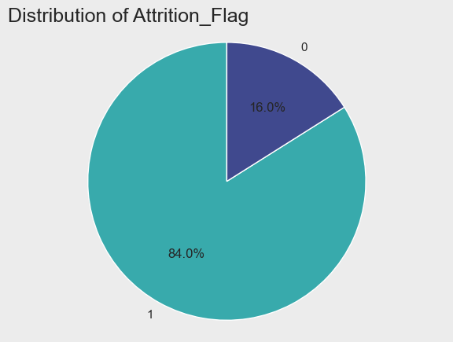

```python
attrition_counts = train_eda['Attrition_Flag'].value_counts()
fig, ax = plt.subplots()
ax.pie(attrition_counts.values, labels=attrition_counts.index, autopct='%1.1f%%',
       startangle=90, colors=sns.color_palette('mako_r',2))
ax.axis('equal')
plt.title('Distribution of Attrition_Flag', size=18, loc='left')
plt.show()
```

**It's clear that the dataset is unbalanced, with a much larger percentage of "1"s than "0"s.**

## 3.1 Explore categorical columns

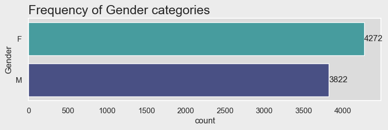

```python
fig, ax  = plt.subplots(figsize=(8,2))
ax=sns.countplot(y='Gender', data=train_eda, palette='mako_r',
				order = train_eda['Gender'].value_counts(normalize=True).index)
ax.set_xticklabels(ax.get_xticklabels())
ax.bar_label(ax.containers[0])
ax.set_title(f'Frequency of Gender categories', size=18, loc='left')
plt.show()
```

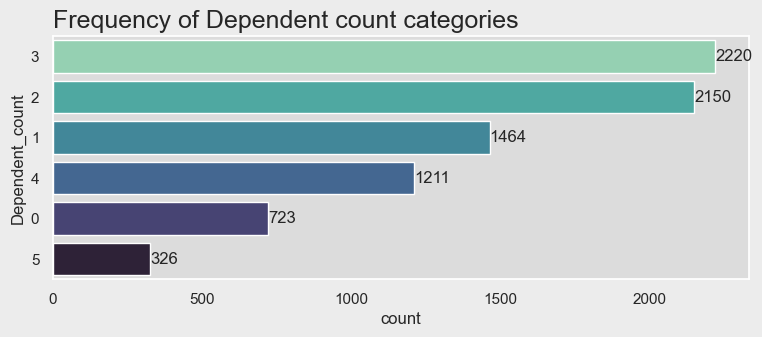

```python
fig, ax  = plt.subplots(figsize=(8,3))
ax=sns.countplot(y='Dependent_count', data=train_eda, palette='mako_r',
				order = train_eda['Dependent_count'].value_counts().index)
ax.set_xticklabels(ax.get_xticklabels())
ax.bar_label(ax.containers[0])
ax.set_title(f'Frequency of Dependent count categories', size=18, loc='left')
plt.show()
```

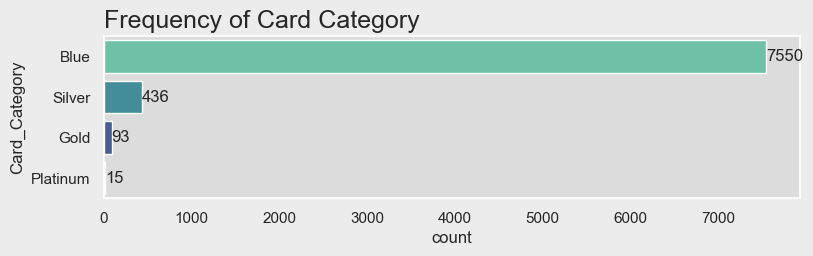

```python
fig, ax  = plt.subplots(figsize=(8,2))
ax=sns.countplot(y='Card_Category', data=train_eda, palette='mako_r',
				order = train_eda['Card_Category'].value_counts().index)
ax.set_xticklabels(ax.get_xticklabels())
ax.bar_label(ax.containers[0])
ax.set_title(f'Frequency of Card Category', size=18, loc='left')
plt.show()
```

**Insights:**

- We have an almost even distribution of females and males in the dataset.
- Almost all the customers in the database have children in their households.
- The vast majority of customers have the blue card, which makes sense because the other cards  
  are typically reserved for special customers, so fewer of them will have it.

## 3.2 Explore numeric columns

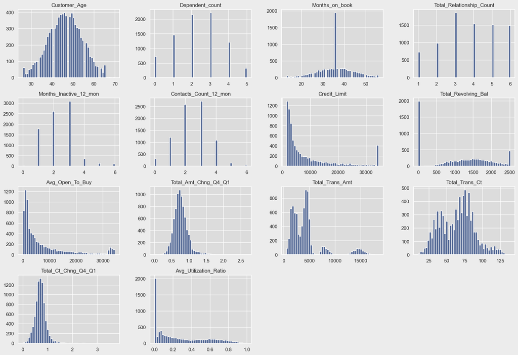

```python
train_eda.select_dtypes('number').drop('Attrition_Flag', axis=1).hist(figsize=(18,13), bins=50,
                                                                      color='#536895')
plt.show()
```

## 3.3 Multivariate Analysis

### 3.3.1 Categorical Variable & Target

**Are there significant differences in characteristics between customers who have left the bank and those who have not?**

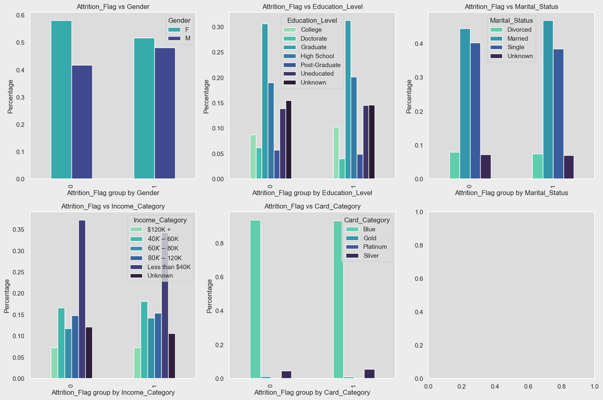

```python
fig, axes = plt.subplots(2, 3, figsize=(15, 10))
fig.subplots_adjust(hspace=0.5)

categorical_features = train.select_dtypes('object')
def groupby_categorical(feature):
  group = train.groupby('Attrition_Flag')[feature].value_counts(normalize=True)
  return group.unstack()

for i, feature in enumerate(categorical_features):
    if i < 5:
        row, col = i // 3, i % 3
        group = groupby_categorical(feature)
        ax = axes[row, col]
        group.plot(kind='bar', color=sns.color_palette('mako_r',len(group.columns)), xlabel=f'Attrition_Flag group by {feature}', ax=ax)
        ax.set_ylabel('Percentage')
        ax.set_title(f'Attrition_Flag vs {feature}')

plt.tight_layout()
plt.show()
```

**Insight:**

I don't see any characteristic that is significantly more prevalent in one group compared to the other.  
Therefore, at this moment, I don't have enough evidence to conclude that the categorical variables, most of  
which are demographic in nature, can be potential predictors of whether a customer will leave the institution.

**Can I determine which categorical variables are more statistically related to the target variable?**

We can create a contingency table for each categorical column alongside the target variable `Attrition_Flag`,  
and then apply a chi-squared test to observe the p-value.

**Our hypotheses are as follows:**

- **H0:** There is no significant relationship between the categorical variables and the target variable, meaning that  
  categorical variables do not influence the probability of the target variable being 0 or 1.
- **H1:** There is a significant relationship between the categorical variables and the target variable, suggesting that  
  categorical variables do influence the probability of the target variable being 0 or 1.

```python
for catcol in train_eda.select_dtypes('object'):
  gdf = train_eda.groupby('Attrition_Flag')[catcol].value_counts().unstack().values
  res = chi2_contingency(gdf)
  print(f'category: {catcol}, statistic: {res.statistic:.4f}, pvalue: {res.pvalue:.4f}')
```

```
category: Gender, statistic: 17.9721, pvalue: 0.0000
category: Education_Level, statistic: 17.7253, pvalue: 0.0070
category: Marital_Status, statistic: 2.6401, pvalue: 0.4505
category: Income_Category, statistic: 11.6446, pvalue: 0.0400
category: Card_Category, statistic: 5.1505, pvalue: 0.1611
```

**Significant variables:**

- **Gender < 0.0000**
- **Education_Level = 0.007**
- **Income_Category = 0.04**

With a p-value less than 0.05, it suggests a significant relationship between these categorical variables  
and the target variable. In other words, categorical variables do influence the probability of the target  
variable being 0 or 1. Therefore, we can reject the null hypothesis for these categories and accept the  
alternative hypothesis.  
**We will take this information into account for subsequent stages when constructing the prediction model.**

### 3.3.2 Numeric variables & Target

**What information about the customer is most correlated with the abandonment rate?**

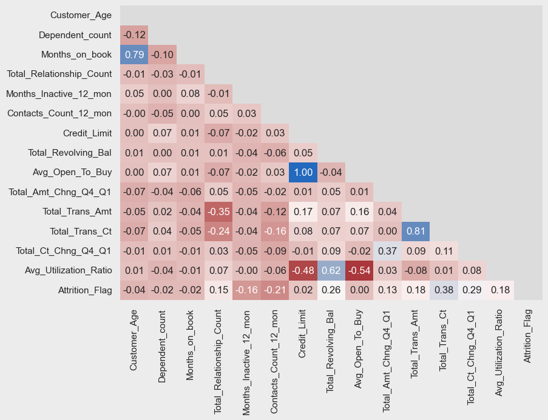

```python
plt.figure(figsize=(8,6))
mask = np.triu(np.ones_like(train_eda.corr(), dtype=bool))
sns.heatmap(train_eda.corr(), annot=True, cmap='vlag_r', fmt='.2f', cbar=False, mask=mask)
plt.show()
```

**Insights:**

- We observe a high correlation between the variables **Total_Revolving_Bal & Avg_Utilization_Ratio**.  
  This correlation is logical since the calculation of the utilization ratio includes the revolving balance as the numerator.
- A similar scenario arises with **Credit_Limit & Avg_Open_To_Buy**, but in this case, the credit limit acts as the subtracted  
  value in the formula.
- **Total_Trans_Amt & Total_Trans_Ct** exhibit a strong correlation. This can be attributed to the fact that, with a higher number  
  of transactions, it is expected that the total transaction amount will also be higher.
- There is also a notable correlation between the variables **Customer_Age & Months_on_Book**. However, in this case, I couldn't  
  identify a clear cause-and-effect relationship.

We are aware of the importance of carefully selecting relevant variables to avoid negative effects such as overfitting and poor performance  
on new data. Nevertheless, sometimes having more variables in a classification model can offer benefits such as the ability to identify  
complex patterns, reduced bias, and increased flexibility. In this case, when testing both approaches, the test set yielded better results  
when including a larger number of variables.

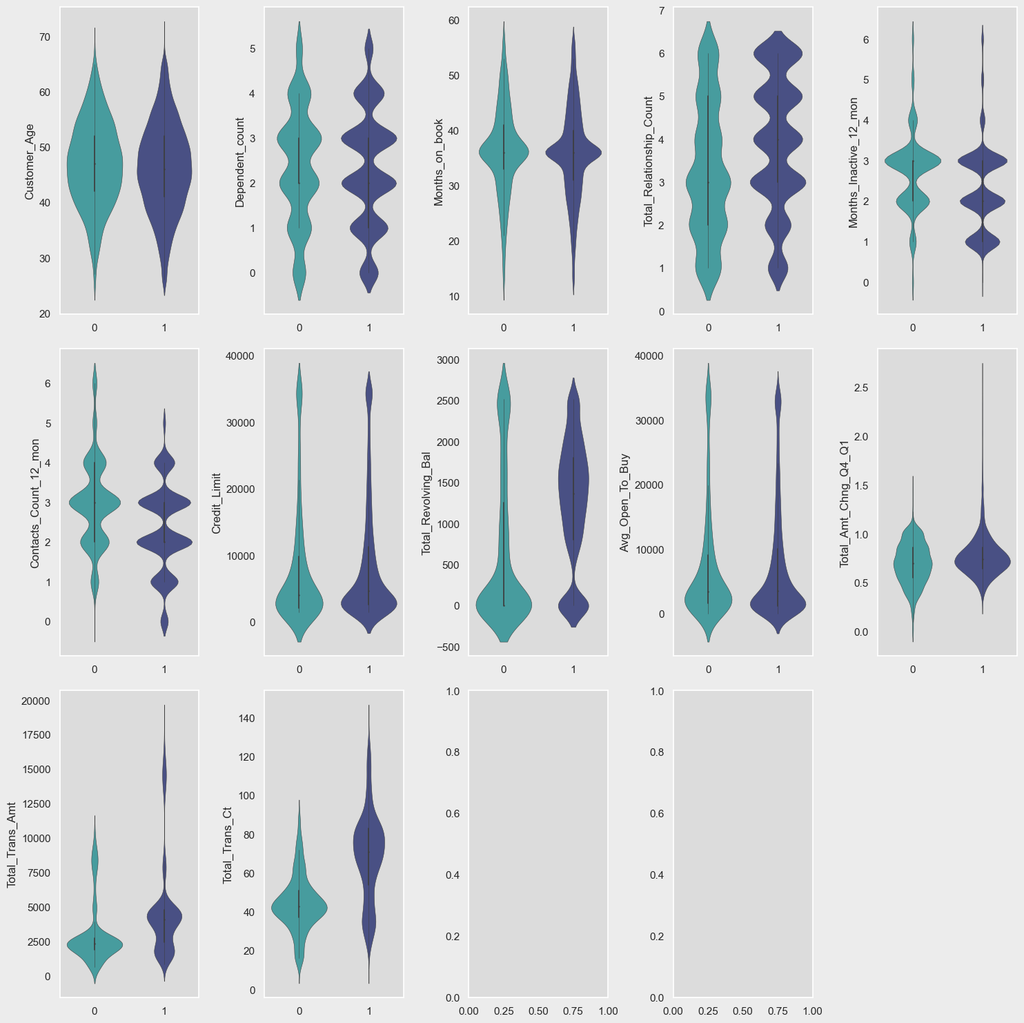

```python
fig, axes = plt.subplots(3, 5, figsize=(15, 15))
fig.subplots_adjust(hspace=0.5)
num_columns = train_eda.select_dtypes(['number']).drop('Attrition_Flag', axis=1)

for i, col in enumerate(num_columns.columns):
    if i < 3 * 4:
        row, col_idx = divmod(i, 5)
        ax = axes[row, col_idx]
        sns.violinplot(data=train_eda, x='Attrition_Flag', y=col,
                    palette=sns.color_palette('mako_r', 2),
                    linewidth=0.4, ax=ax)
        ax.set_xlabel(None)

for i in range(len(num_columns.columns), 3 * 5):
    fig.delaxes(axes.flatten()[i])

plt.tight_layout()
plt.show()
```

**Insights:**

- **Number of relationships.** Customers who have left the bank had slightly less contact with the card provider.
- **Credit Limit & Revolving Balance.**Customers who have left the bank had slightly lower credit limit, as well as lower  
  revolving balance (this may be related to them having lower credit limit, we can check this with the variable **Avg_Open_To_Buy**,  
  which is very similar for both groups).
- **Total transaction amount and Total transaction count.** Customers who have left the bank had lower amount and number of  
  transactions compared to those who stay.
- **Utilization Ratio.**Customers who have left had lower ratio compared to those who stay.

**Combining more than 2 variables**

```python
# Nivel de educación y género
groupnested = train_eda.groupby(['Education_Level','Gender','Attrition_Flag']).size().unstack()
groupnested['total'] = groupnested.sum(1)
groupnested[0] = round(groupnested.loc[:,0]/groupnested['total']*100,2)
groupnested[1] = round(groupnested.loc[:,1]/groupnested['total']*100,2)
groupnested.style.background_gradient(cmap='Blues')
```

| Education_Level | Attrition_Flag Gender | 0 | 1 | total |
| --- | --- | --- | --- | --- |
| College | F | 14.010000 | 85.990000 | 421 |
|  | M | 13.920000 | 86.080000 | 395 |
| Doctorate | F | 25.850000 | 74.150000 | 205 |
|  | M | 18.670000 | 81.330000 | 150 |
| Graduate | F | 18.010000 | 81.990000 | 1349 |
|  | M | 13.230000 | 86.770000 | 1179 |
| High School | F | 17.410000 | 82.590000 | 827 |
|  | M | 13.130000 | 86.870000 | 792 |
| Post-Graduate | F | 17.730000 | 82.270000 | 203 |
|  | M | 18.630000 | 81.370000 | 204 |
| Uneducated | F | 16.090000 | 83.910000 | 634 |
|  | M | 14.710000 | 85.290000 | 537 |
| Unknown | F | 18.800000 | 81.200000 | 633 |
|  | M | 14.690000 | 85.310000 | 565 |

```python
# Nivel de ingresos y género
groupnested2 = train.groupby(['Income_Category','Gender','Attrition_Flag']).size().unstack()
groupnested2['total'] = groupnested2.sum(1)
groupnested2[0] = round(groupnested2.loc[:,0]/groupnested2['total']*100,2)
groupnested2[1] = round(groupnested2.loc[:,1]/groupnested2['total']*100,2)
groupnested2.style.background_gradient(cmap='Blues')
```

| Income_Category | Attrition_Flag Gender | 0 | 1 | total |
| --- | --- | --- | --- | --- |
| $120K + | M | 16.160000 | 83.840000 | 588 |
| $40K - $60K | F | 16.710000 | 83.290000 | 832 |
|  | M | 12.400000 | 87.600000 | 621 |
| $60K - $80K | M | 13.640000 | 86.360000 | 1122 |
| $80K - $120K | M | 15.600000 | 84.400000 | 1237 |
| Less than $40K | F | 17.880000 | 82.120000 | 2595 |
|  | M | 9.220000 | 90.780000 | 217 |
| Unknown | F | 18.110000 | 81.890000 | 845 |
|  | M | 13.510000 | 86.490000 | 37 |

**Insights:**

- In the majority of cases, women are slightly more likely to churn from the bank.
- The highest churn rate is found among women with a doctoral degree.
- The churn rate for men with low incomes is quite low.

We will proceed to prepare the data, for further modeling with some classification algorithms and seeing the outcome  
of each of these.

# 4. Preprocess Data

```python
train['Attrition_Flag'] = train['Attrition_Flag'].astype(int)

# Drop the same rows and columns for the test dataset
drop_rows_cols(test)

# Separate X and Y in the train dataset
X = train.drop('Attrition_Flag', axis=1)
y_train = train.loc[:,'Attrition_Flag']

# StandardScaler for numerical columns
sc = StandardScaler()
X_train_num = sc.fit_transform(X.select_dtypes('number'))
X_test_num = sc.fit_transform(test.select_dtypes('number'))

# OneHotEncoder for categorical columns
ohe = OneHotEncoder(handle_unknown='ignore', drop='first', sparse_output=False)
X_train_str = ohe.fit_transform(X.select_dtypes(exclude='number'))
X_test_str = ohe.transform(test.select_dtypes(exclude='number'))

# Column names
column_names = sc.feature_names_in_.tolist() + ohe.get_feature_names_out().tolist()

# Concatenate the datasets
X_train = pd.DataFrame(np.c_[X_train_num,X_train_str], columns=column_names)
X_test = pd.DataFrame(np.c_[X_test_num,X_test_str], columns=column_names)
```

**Let's take a look of the first 3 rows**

```python
X_train.head(3)
```

|  | Customer_Age | Dependent_count | Months_on_book | Total_Relationship_Count | Months_Inactive_12_mon | Contacts_Count_12_mon | Credit_Limit | Total_Revolving_Bal | Avg_Open_To_Buy | Total_Amt_Chng_Q4_Q1 | Total_Trans_Amt | Total_Trans_Ct | Total_Ct_Chng_Q4_Q1 | Avg_Utilization_Ratio | Gender_M | Education_Level_Doctorate | Education_Level_Graduate | Education_Level_High School | Education_Level_Post-Graduate | Education_Level_Uneducated | Education_Level_Unknown | Marital_Status_Married | Marital_Status_Single | Marital_Status_Unknown | Income_Category_$40K - $60K | Income_Category_$60K - $80K | Income_Category_$80K - $120K | Income_Category_Less than $40K | Income_Category_Unknown | … |
| --- | --- | --- | --- | --- | --- | --- | --- | --- | --- | --- | --- | --- | --- | --- | --- | --- | --- | --- | --- | --- | --- | --- | --- | --- | --- | --- | --- | --- | --- | --- |
| 0 | 0.959156 | -1.035609 | 0.009330 | -1.812384 | 0.643919 | 0.499129 | -0.540664 | 0.696394 | -0.603556 | -0.765389 | 1.220535 | 1.446968 | -0.142715 | 0.694797 | 0.0 | 0.0 | 0.0 | 0.0 | 0.0 | 0.0 | 1.0 | 0.0 | 1.0 | 0.0 | 0.0 | 0.0 | 0.0 | 0.0 | 1.0 | … |
| 1 | 1.458033 | 1.291924 | 1.504761 | -1.812384 | 1.629898 | 0.499129 | -0.356587 | 0.788382 | -0.427609 | -1.236213 | -0.675056 | -1.099749 | -1.334368 | 0.221376 | 0.0 | 0.0 | 0.0 | 1.0 | 0.0 | 0.0 | 0.0 | 1.0 | 0.0 | 0.0 | 0.0 | 0.0 | 0.0 | 0.0 | 1.0 | … |
| 2 | -0.163319 | 1.291924 | 0.009330 | 1.409544 | -1.328038 | 0.499129 | 0.808719 | 0.598273 | 0.755575 | -0.133008 | -0.872348 | -1.227085 | 2.248954 | -0.619859 | 0.0 | 0.0 | 0.0 | 0.0 | 0.0 | 0.0 | 1.0 | 0.0 | 1.0 | 0.0 | 0.0 | 0.0 | 0.0 | 1.0 | 0.0 | … |

# 5. Modeling

For the churn prediction task, it's crucial to choose the appropriate classification algorithm.  
Among the algorithms we will evaluate are logistic regression, Random Forest, and Gradient Boosting.  
Each of them has strengths and weaknesses in terms of complexity, ability to handle large and complex  
datasets, model interpretability, and required accuracy.

```python
def display_cv_results(model):
    print("Best hyperparameters: ",model.best_params_)
    print("Best score :",np.round(model.best_score_,4))
    print("Average score: ",np.round(np.nanmean(model.cv_results_['mean_test_score']),4))
    print("Average Standard Deviation of scores: ",np.round(np.nanstd(model.cv_results_['mean_test_score']),4))
```

## 5.1 Logistic Regression

```python
param_grid  = {"C":[0.01,0.1,1],
          'penalty':['none', 'l1', 'l2', 'elasticnet'],
          'solver':['lbfgs', 'liblinear', 'newton-cg', 'newton-cholesky', 'sag', 'saga']}

lr = LogisticRegression()
lr_random = RandomizedSearchCV(lr, scoring = 'f1_macro',
                                param_distributions = param_grid,
                                cv = 5,
                                n_iter = 200,
                                verbose=2,
                                random_state=42,
                                n_jobs = -1 )
lr_random.fit(X_train,y_train);
```

```
Fitting 5 folds for each of 72 candidates, totalling 360 fits
```

```python
display_cv_results(lr_random)
```

```
Best hyperparameters:  {'solver': 'lbfgs', 'penalty': 'none', 'C': 0.01}
Best score : 0.8042
Average score:  0.7969
Average Standard Deviation of scores:  0.0128
```

## 5.2 Random Forest

```python
rf = RandomForestClassifier()

n_estimators = [int(x) for x in np.linspace(start = 200, stop = 2000, num = 10)]
max_features = ['auto', 'sqrt']
max_depth = [int(x) for x in np.linspace(10, 110, num = 11)]
max_depth.append(None)
min_samples_split = [2, 5, 10]
min_samples_leaf = [1, 2, 4]
bootstrap = [True, False]

random_grid = {'n_estimators': n_estimators,
               'max_features': max_features,
               'max_depth': max_depth,
               'min_samples_split': min_samples_split,
               'min_samples_leaf': min_samples_leaf,
               'bootstrap': bootstrap}

rf_random = RandomizedSearchCV(estimator = rf,
                                param_distributions = random_grid,
                                n_iter = 10,
                                cv = 3,
                                verbose=2,
                                random_state=42,
                                n_jobs = -1,
                                scoring='f1_macro')

rf_random.fit(X_train, y_train);
```

```
Fitting 3 folds for each of 10 candidates, totalling 30 fits
```

```
RandomizedSearchCV(cv=3, estimator=RandomForestClassifier(), n_jobs=-1,
                   param_distributions={'bootstrap': [True, False],
                                        'max_depth': [10, 20, 30, 40, 50, 60,
                                                      70, 80, 90, 100, 110,
                                                      None],
                                        'max_features': ['auto', 'sqrt'],
                                        'min_samples_leaf': [1, 2, 4],
                                        'min_samples_split': [2, 5, 10],
                                        'n_estimators': [200, 400, 600, 800,
                                                         1000, 1200, 1400, 1600,
                                                         1800, 2000]},
                   random_state=42, scoring='f1_macro', verbose=2)
```

```python
display_cv_results(rf_random)
```

```
Best hyperparameters:  {'n_estimators': 2000, 'min_samples_split': 2, 'min_samples_leaf': 2, 'max_features': 'auto', 'max_depth': 50, 'bootstrap': False}
Best score : 0.9191
Average score:  0.9077
Average Standard Deviation of scores:  0.0111
```

## 5.3 Gradient Booster

Gradient Boosting is an accurate technique and capable of handling complex and large data sets,  
making it ideal for binary classification problems. Additionally, it can handle missing data and outliers,  
and is able to identify important features in the data.

For more information you can consult more information in the scikit-learn documentation:  
https://scikit-learn.org/stable/modules/generated/sklearn.ensemble.GradientBoostingClassifier.html

```python
gb = GradientBoostingClassifier()

param_grid = {'n_estimators': [int(x) for x in np.linspace(start = 200, stop = 2600, num = 8)],
         'max_depth': [int(x) for x in np.linspace(5, 60, num = 12)],
         'max_features': ['auto', 'sqrt', 'log2']}

gb_random = RandomizedSearchCV(gb,
                                scoring = 'f1_macro',
                                param_distributions = param_grid,
                                cv = 5,
                                n_iter = 10,
                                verbose=2,
                                random_state=42,
                                n_jobs = -1
                                )

gb_random.fit(X_train,y_train);
```

```
Fitting 5 folds for each of 10 candidates, totalling 50 fits
```

```
RandomizedSearchCV(cv=5, estimator=GradientBoostingClassifier(), n_jobs=-1,
                   param_distributions={'max_depth': [5, 10, 15, 20, 25, 30, 35,
                                                      40, 45, 50, 55, 60],
                                        'max_features': ['auto', 'sqrt',
                                                         'log2'],
                                        'n_estimators': [200, 542, 885, 1228,
                                                         1571, 1914, 2257,
                                                         2600]},
                   random_state=42, scoring='f1_macro', verbose=2)
```

```python
display_cv_results(gb_random)
```

```
Best hyperparameters:  {'n_estimators': 542, 'max_features': 'sqrt', 'max_depth': 5}
Best score : 0.9499
Average score:  0.9169
Average Standard Deviation of scores:  0.0225
```

# 6. Conclusions & Submission

## 6.1 Submission

```python
y_predict = gb_random.best_estimator_.predict(X_test)
submission = pd.DataFrame(y_predict, columns =['target'])
submission.head()
```

|  | target |
| --- | --- |
| 0 | 1 |
| 1 | 1 |
| 2 | 1 |
| 3 | 1 |
| 4 | 1 |

```python
submission.to_json('predictions.json', indent=4)
```